# Tractor Analysis

This demonstration will create an html document with the results of the analysis of used tractor prices. This document can be viewed in any internet browser.

## Parameters

The header of the `qmd` file for this document declares several settings for the generation of the Quarto report. The `format: html` option and `toc: true` will generate a table of contents based on the headings in the document, complete with links to those sections.

Other parameters relate to formatting and determine what is rendered in the document. The `echo: false` option disables the printing of code, so that only the output is displayed. The `warning: false` option suppresses any warning messages, which are the analyst’s business but would not appear in a presentation (assuming the analysts has solved any related problems, of course).

# Analysis of Used Tractor Sales

## Preparing the Workspace

First, I loaded the required packages, for which it is not necessary to print output.

## Initial Inspection of the Data

Then I read in all the data and joined it together, then generated new variables, all in one command.

```
     saleID        saleprice           age           enghours
 Min.   :101.0   Min.   :  1500   Min.   : 2.00   Min.   :    1.0
 1st Qu.:169.8   1st Qu.:  7750   1st Qu.: 7.00   1st Qu.:  777.2
 Median :238.5   Median : 12000   Median :15.00   Median : 2398.0
 Mean   :238.5   Mean   : 20747   Mean   :15.91   Mean   : 3530.2
 3rd Qu.:307.2   3rd Qu.: 20925   3rd Qu.:24.00   3rd Qu.: 5409.8
 Max.   :376.0   Max.   :200000   Max.   :33.00   Max.   :18744.0

   johndeere          spring           summer           winter
 Min.   :0.0000   Min.   :0.0000   Min.   :0.0000   Min.   :0.0000
 1st Qu.:0.0000   1st Qu.:0.0000   1st Qu.:0.0000   1st Qu.:0.0000
 Median :0.0000   Median :0.0000   Median :0.0000   Median :0.0000
 Mean   :0.1413   Mean   :0.2246   Mean   :0.2319   Mean   :0.1703
 3rd Qu.:0.0000   3rd Qu.:0.0000   3rd Qu.:0.0000   3rd Qu.:0.0000
 Max.   :1.0000   Max.   :1.0000   Max.   :1.0000   Max.   :1.0000

   horsepower         diesel            fwd             manual
 Min.   : 16.00   Min.   :0.0000   Min.   :0.0000   Min.   :0.0000
 1st Qu.: 47.75   1st Qu.:1.0000   1st Qu.:0.0000   1st Qu.:0.0000
 Median : 80.00   Median :1.0000   Median :1.0000   Median :1.0000
 Mean   :101.06   Mean   :0.9094   Mean   :0.5652   Mean   :0.7029
 3rd Qu.:108.50   3rd Qu.:1.0000   3rd Qu.:1.0000   3rd Qu.:1.0000
 Max.   :535.00   Max.   :1.0000   Max.   :1.0000   Max.   :1.0000

      cab            cab_orig   log_saleprice    squared_horsepower
 Min.   :0.0000   Min.   :1     Min.   : 7.313   Min.   :   256
 1st Qu.:0.0000   1st Qu.:1     1st Qu.: 8.955   1st Qu.:  2280
 Median :1.0000   Median :1     Median : 9.393   Median :  6400
 Mean   :0.5435   Mean   :1     Mean   : 9.484   Mean   : 17347
 3rd Qu.:1.0000   3rd Qu.:1     3rd Qu.: 9.949   3rd Qu.: 11773
 Max.   :1.0000   Max.   :1     Max.   :12.206   Max.   :286225
                  NA's   :126
```

## Choosing the Dependent Variable

### Plotting the Variables

First, plot a histogram of the tractor prices, without any transformation. This time, I will use the `geom_histogram` function from the `ggplot2` graphics library in the tidyverse.

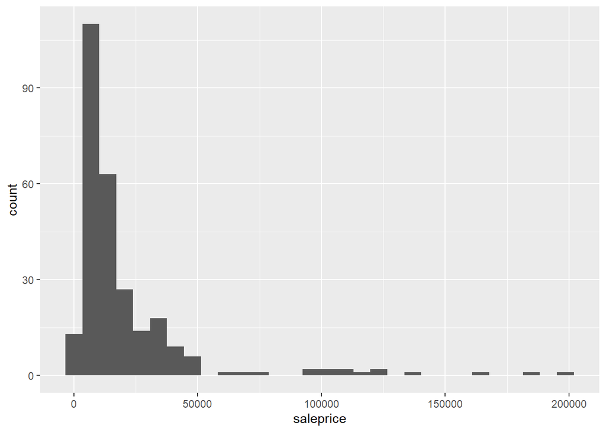

Notice that there are some very large values. The distribution is highly skewed. Then, I considered taking logs to bring the outliers closer to the others.

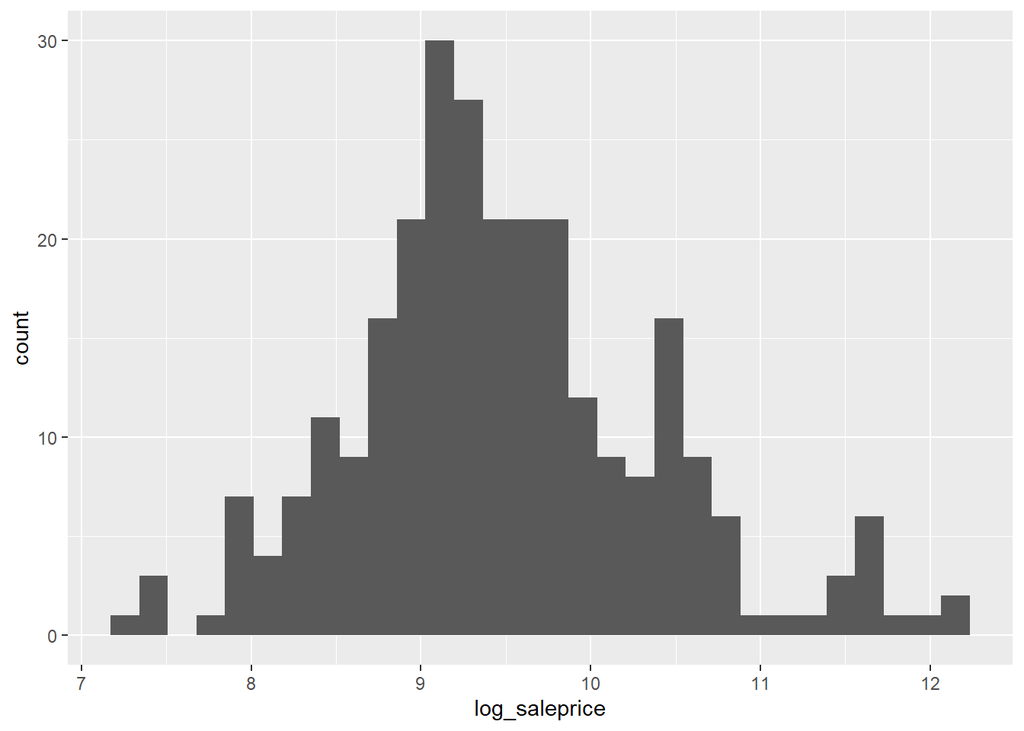

This looks much better behaved: the distribution is nearly symmetric and it has a normal shape. I would consider this as the dependent variable on these grounds alone. However, we can estimate two models to gather more evidence for this decision.

### Comparison with Regression Models

The first regression model is a linear model for dollar sale price.

```
Call:
lm(formula = saleprice ~ horsepower + age + enghours + diesel +
    fwd + manual + johndeere + cab + spring + summer + winter,
    data = tractor_data)

Residuals:
   Min     1Q Median     3Q    Max
-48532  -6089   -645   6263  92806

Coefficients:
              Estimate Std. Error t value Pr(>|t|)
(Intercept) 13015.7894  4468.2593   2.913  0.00389 **
horsepower    226.5840    15.1670  14.939  < 2e-16 ***
age          -699.7279   146.8462  -4.765 3.12e-06 ***
enghours       -1.9344     0.3934  -4.917 1.55e-06 ***
diesel        444.3901  4000.6502   0.111  0.91164
fwd          1491.0701  2413.9374   0.618  0.53731
manual      -4214.1008  2550.8076  -1.652  0.09971 .
johndeere   13709.8757  2972.6862   4.612 6.22e-06 ***
cab          8072.0643  2597.6376   3.107  0.00209 **
spring      -1815.2076  2672.9042  -0.679  0.49766
summer      -4923.8739  2620.8553  -1.879  0.06138 .
winter      -1579.6222  2933.8039  -0.538  0.59074
---
Signif. codes:  0 '***' 0.001 '**' 0.01 '*' 0.05 '.' 0.1 ' ' 1

Residual standard error: 16380 on 264 degrees of freedom
Multiple R-squared:  0.6599,    Adjusted R-squared:  0.6457
F-statistic: 46.57 on 11 and 264 DF,  p-value: < 2.2e-16
```

The next regression model is a linear model of the logarithm of the sale price.

```
Call:
lm(formula = log_saleprice ~ horsepower + age + enghours + diesel +
    fwd + manual + johndeere + cab + spring + summer + winter,
    data = tractor_data)

Residuals:
     Min       1Q   Median       3Q      Max
-1.71650 -0.26774  0.05876  0.29463  0.91906

Coefficients:
              Estimate Std. Error t value Pr(>|t|)
(Intercept)  8.881e+00  1.163e-01  76.390  < 2e-16 ***
horsepower   4.892e-03  3.946e-04  12.397  < 2e-16 ***
age         -2.962e-02  3.821e-03  -7.753 1.95e-13 ***
enghours    -3.584e-05  1.024e-05  -3.502 0.000543 ***
diesel       3.094e-01  1.041e-01   2.972 0.003231 **
fwd          2.672e-01  6.281e-02   4.253 2.93e-05 ***
manual      -1.632e-01  6.637e-02  -2.459 0.014562 *
johndeere    2.983e-01  7.735e-02   3.856 0.000145 ***
cab          6.697e-01  6.759e-02   9.909  < 2e-16 ***
spring      -3.992e-02  6.955e-02  -0.574 0.566468
summer      -6.520e-02  6.819e-02  -0.956 0.339895
winter       3.697e-02  7.634e-02   0.484 0.628554
---
Signif. codes:  0 '***' 0.001 '**' 0.01 '*' 0.05 '.' 0.1 ' ' 1

Residual standard error: 0.4262 on 264 degrees of freedom
Multiple R-squared:  0.7792,    Adjusted R-squared:   0.77
F-statistic:  84.7 on 11 and 264 DF,  p-value: < 2.2e-16
```

This model suggests that the premium for a John Deere tractor is 30 percent above the value of a similar tractor of another brand. This models makes much more sense, so we will use the logarithmic transformation of the sales price as the dependent variable. With this model, the coefficients are interpreted as percentage changes in the value of tractors. Also, the R-squared is higher, even though it is not a direct comparison, since the dependent variable is different. Still, this model looks more promising.

## Nonlinear Specification of Horsepower

Consider a polynomial functional form for horsepower. The idea, suggested by a tractor dealer, is that horsepower improves performance up to a limit, then the extra power does not add much value, but still consumes more fuel, so it is more expensive to operate.

If this theory is true, we expect that the coefficient for `horsepower` is positive and that the coefficient for `squared_horsepower` is negative. These are the results:

```
Call:
lm(formula = log_saleprice ~ horsepower + squared_horsepower +
    age + enghours + diesel + fwd + manual + johndeere + cab +
    spring + summer + winter, data = tractor_data)

Residuals:
     Min       1Q   Median       3Q      Max
-1.69989 -0.23404  0.05332  0.29651  0.74608

Coefficients:
                     Estimate Std. Error t value Pr(>|t|)
(Intercept)         8.726e+00  1.116e-01  78.212  < 2e-16 ***
horsepower          1.115e-02  1.070e-03  10.422  < 2e-16 ***
squared_horsepower -1.409e-05  2.261e-06  -6.231 1.83e-09 ***
age                -3.206e-02  3.595e-03  -8.919  < 2e-16 ***
enghours           -4.086e-05  9.607e-06  -4.253 2.93e-05 ***
diesel              2.145e-01  9.854e-02   2.177   0.0304 *
fwd                 2.753e-01  5.876e-02   4.685 4.50e-06 ***
manual             -1.531e-01  6.209e-02  -2.465   0.0143 *
johndeere           3.097e-01  7.236e-02   4.280 2.62e-05 ***
cab                 4.779e-01  7.031e-02   6.796 7.17e-11 ***
spring             -4.892e-02  6.506e-02  -0.752   0.4527
summer             -5.729e-02  6.379e-02  -0.898   0.3700
winter              4.596e-02  7.141e-02   0.644   0.5204
---
Signif. codes:  0 '***' 0.001 '**' 0.01 '*' 0.05 '.' 0.1 ' ' 1

Residual standard error: 0.3986 on 263 degrees of freedom
Multiple R-squared:  0.8076,    Adjusted R-squared:  0.7988
F-statistic:    92 on 12 and 263 DF,  p-value: < 2.2e-16
```

Both coefficients are significant and the signs are as expected, which supports the theory of the polynomial form for the value of horsepower.

## Seasonal Indicators

Since the seasonal indicators do not appear to be significant, estimate the model without those indicators.

```
Call:
lm(formula = log_saleprice ~ horsepower + squared_horsepower +
    age + enghours + diesel + fwd + manual + johndeere + cab,
    data = tractor_data)

Residuals:
     Min       1Q   Median       3Q      Max
-1.63939 -0.22779  0.04313  0.27805  0.80619

Coefficients:
                     Estimate Std. Error t value Pr(>|t|)
(Intercept)         8.728e+00  1.060e-01  82.327  < 2e-16 ***
horsepower          1.112e-02  1.067e-03  10.423  < 2e-16 ***
squared_horsepower -1.404e-05  2.255e-06  -6.223 1.89e-09 ***
age                -3.233e-02  3.580e-03  -9.031  < 2e-16 ***
enghours           -4.178e-05  9.569e-06  -4.367 1.81e-05 ***
diesel              2.035e-01  9.805e-02   2.076   0.0389 *
fwd                 2.654e-01  5.820e-02   4.560 7.82e-06 ***
manual             -1.502e-01  6.189e-02  -2.426   0.0159 *
johndeere           3.187e-01  7.186e-02   4.435 1.35e-05 ***
cab                 4.834e-01  7.003e-02   6.903 3.72e-11 ***
---
Signif. codes:  0 '***' 0.001 '**' 0.01 '*' 0.05 '.' 0.1 ' ' 1

Residual standard error: 0.3981 on 266 degrees of freedom
Multiple R-squared:  0.8059,    Adjusted R-squared:  0.7993
F-statistic: 122.7 on 9 and 266 DF,  p-value: < 2.2e-16
```

## Conclusions

With this model, we see that the value of a tractor has a polynomial relationship with horsepower: the value increases to a point, then declines as tractors with higher horsepower are more expensive to operate.

The values of tractors decline as they age, losing about 3 percent of value each year. The value of tractors also declines with more use, declining about 4 percent for every thousand hours of use.

In terms of the features of the tractor, tractors that run on diesel fuel ar worth about 20 percent more than a similar tractor that runs on gasoline. A four-wheel drivetrain adds about 26 percent to the value of a tractor. A tractor with manual transmission is worth about 15 percent less than one with a manual transmission. A tractor with a cab is worth about 48 percent more than a similar tractor without a cab.

Finally, a John Deere tractor is worth about 32 percent more than a similar tractor of another brand.